# ST2195 Coursework Part 2

Nicholas Koh

2024-03-29

### Load Relevant Libraries

```r
library(DBI)
library(ggplot2)
library(dplyr)
library(dbplyr)
library(geosphere)
```

### Establish database connection using RSQLite package

```r
conn <- dbConnect(RSQLite::SQLite(), "flights_r.db")
```

### Read data from CSV files into respective names

```r
airports <- read.csv("airports.csv", header = TRUE)
carriers <- read.csv("carriers.csv", header = TRUE)
planes <- read.csv("plane-data.csv", header = TRUE)
```

### Loop to create a table in the database

```r
# Iterate over 10 years (1997 to 2006) to read and process CSV files in the format "year.csv.bz2"
# Data from these files are then written into "flights" table in SQLite database
for(i in c(1997:2006)) {
  filename <- paste0(i, ".csv.bz2")
  print(paste("Processing:", filename))
  flights <- read.csv(filename, header = TRUE)
  if(i == 1997) {
    dbWriteTable(conn, "flights", flights)
  } else {
    dbWriteTable(conn, "flights", flights, append = TRUE)
  }
}
```

### List and check each table and fields in the connected SQLite database

```r
dbListTables(conn)
```

```
## [1] "airports"       "airports.csv"   "carriers"       "carriers.csv"
## [5] "flights"        "ontime"         "plane-data.csv" "planes"
```

```r
dbListFields(conn, "flights")
```

```
##  [1] "Year"              "Month"             "DayofMonth"
##  [4] "DayOfWeek"         "DepTime"           "CRSDepTime"
##  [7] "ArrTime"           "CRSArrTime"        "UniqueCarrier"
## [10] "FlightNum"         "TailNum"           "ActualElapsedTime"
## [13] "CRSElapsedTime"    "AirTime"           "ArrDelay"
## [16] "DepDelay"          "Origin"            "Dest"
## [19] "Distance"          "TaxiIn"            "TaxiOut"
## [22] "Cancelled"         "CancellationCode"  "Diverted"
## [25] "CarrierDelay"      "WeatherDelay"      "NASDelay"
## [28] "SecurityDelay"     "LateAircraftDelay"
```

```r
dbListFields(conn, "airports")
```

```
## [1] "iata"    "airport" "city"    "state"   "country" "lat"     "long"
```

```r
dbListFields(conn, "carriers")
```

```
## [1] "Code"        "Description"
```

```r
dbListFields(conn, "planes")
```

```
## [1] "tailnum"       "type"          "manufacturer"  "issue_date"
## [5] "model"         "status"        "aircraft_type" "engine_type"
## [9] "year"
```

## Part a)

### Query to calculate average delay for each time interval, day of week, and year

*This SQL query calculates the average delay for flights within specific time intervals (0000-0359, 0400-0759, 0800-1159, 1200-1559, 1600-1959, 2000-2359) on each day of the week and for each year between 1997 and 2006. It groups the data by year, day of the week, and time interval, then calculates the average delay (using the ‘avg_delay’ variable) for each group.*

```r
q1 <- paste0("
  SELECT year, dayofweek,
         CASE
           WHEN deptime BETWEEN '0000' AND '0359' THEN '0000-0359'
           WHEN deptime BETWEEN '0400' AND '0759' THEN '0400-0759'
           WHEN deptime BETWEEN '0800' AND '1159' THEN '0800-1159'
           WHEN deptime BETWEEN '1200' AND '1559' THEN '1200-1559'
           WHEN deptime BETWEEN '1600' AND '1959' THEN '1600-1959'
           WHEN deptime BETWEEN '2000' AND '2359' THEN '2000-2359'
         END AS time_interval,
         AVG(depdelay) AS avg_delay
  FROM flights
  WHERE year BETWEEN 1997 AND 2006 AND deptime <= '2359'
  GROUP BY year, dayofweek, time_interval
")
```

### Execute the query

```r
q1 <- dbGetQuery(conn, q1)
```

### View results of the query

```r
View(q1)
```

### Construct a boxplot

*To visualise distribution of delay for each day of the week*

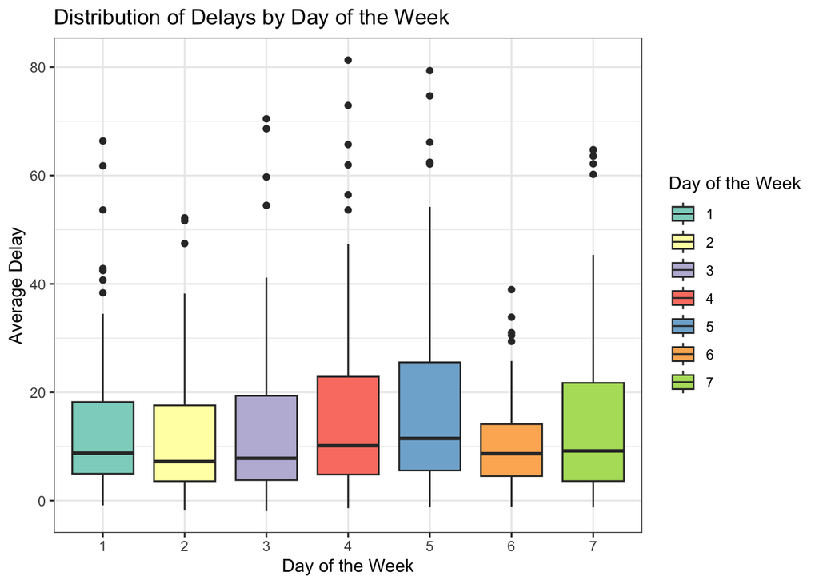

```r
ggplot(q1, aes(x = factor(DayOfWeek), y = avg_delay, fill = factor(DayOfWeek))) +
  geom_boxplot() +
  scale_fill_brewer(palette = "Set3") +
  labs(title = "Distribution of Delays by Day of the Week",
       x = "Day of the Week",
       y = "Average Delay",
       fill = "Day of the Week") +
  theme_bw()
```

### Convert ‘time_interval’ to factor

*This ensures correct ordering of data*

```r
q1$time_interval <- factor(q1$time_interval, levels = unique(q1$time_interval))
```

### Construct a heat map for each year

*Each tile represents the avg delay for the corresponding time interval, day of week and year*

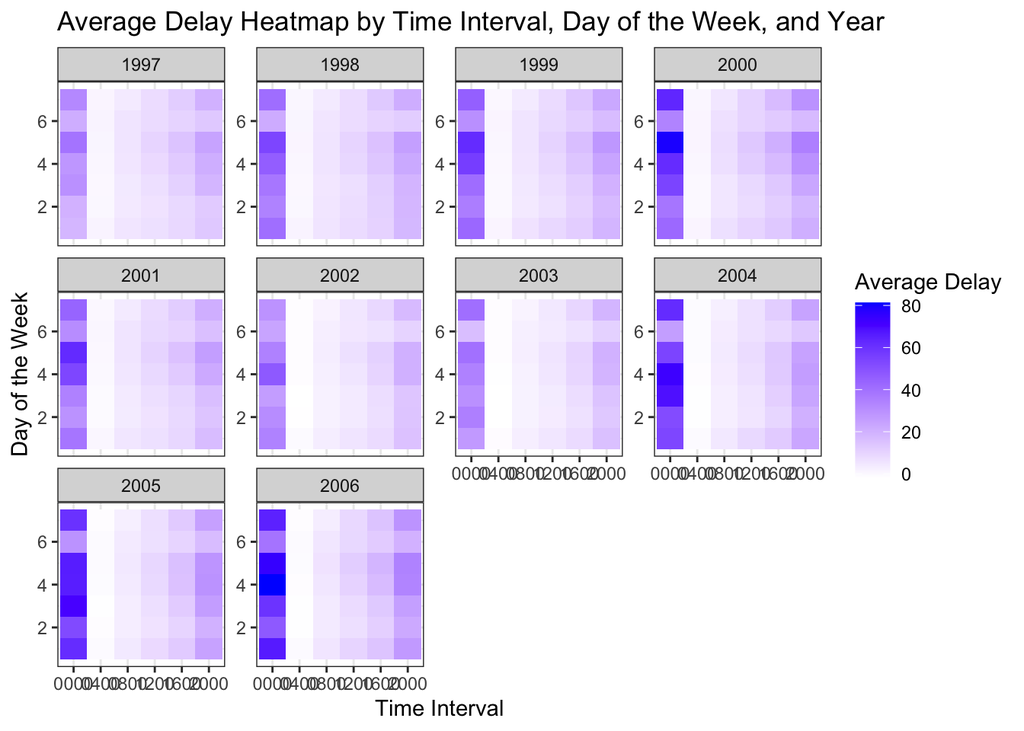

```r
ggplot(q1, aes(x = time_interval, y = DayOfWeek, fill = avg_delay)) +
  geom_tile() +
  scale_fill_gradient(low = "white", high = "blue") +
  facet_wrap(~Year, scales = "free_y") +
  labs(title = "Average Delay Heatmap by Time Interval, Day of the Week, and Year",
       x = "Time Interval",
       y = "Day of the Week",
       fill = "Average Delay") +
  theme_bw() +
  scale_x_discrete(labels = c('0000', '0400', '0800', '1200', '1600', '2000'))
```

## Part b)

### Query to calculate average delay according to each associated plane age, and removing anomalies

```r
q2 <- dbGetQuery(conn, "
    SELECT
        (f.year - p.year) AS plane_age,
        AVG(f.depdelay) AS avg_delay
    FROM
        flights AS f
    INNER JOIN
        planes AS p ON f.tailnum = p.tailnum
    WHERE
        f.depdelay IS NOT NULL
        AND p.year IS NOT NULL
        AND p.year NOT IN ('', 'None', '0000')
        AND (f.year - p.year) >= 0  -- Ensure positive plane_age values
        AND LENGTH(p.year) = 4      -- Ensure p.year is a 4-digit number
    GROUP BY
        plane_age
")
```

### Calculate correlation coefficient

```r
correlation <- cor(q2$plane_age, q2$avg_delay)
```

### Create a scatter plot

*This ggplot2 code creates a scatter plot (geom_point()) with a trend line (geom_smooth(method = “lm”, se = FALSE)) representing the relationship between the age of the plane (plane_age) and the average delay (avg_delay). It also adds a title (labs(title = …)) that includes the correlation coefficient (correlation) rounded to two decimal places, and labels for the x-axis (Plane Age) and y-axis (Average Delay).*

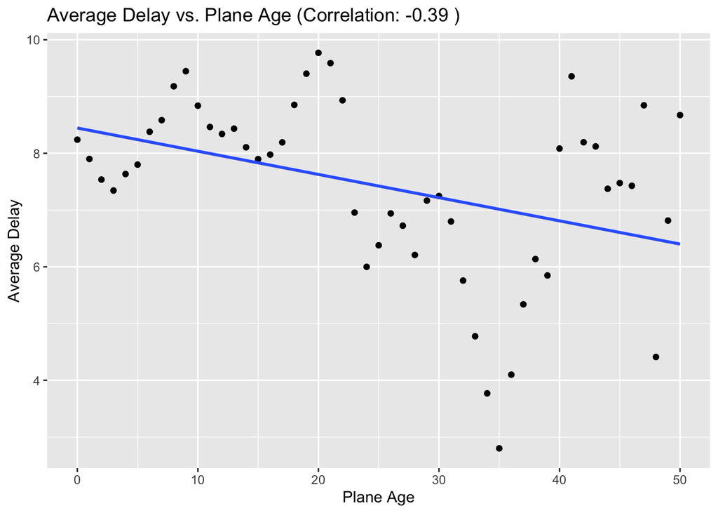

```r
ggplot(q2, aes(x = plane_age, y = avg_delay)) +
  geom_point() +
  geom_smooth(method = "lm", se = FALSE) +
  labs(title = paste("Average Delay vs. Plane Age (Correlation:", round(correlation, 2), ")"),
       x = "Plane Age",
       y = "Average Delay")
```

## Part c)

### Use dbplyr to create a database table abstraction

```r
flights_db <- tbl(conn, "flights")
```

### Load data from the database tables

```r
airports <- tbl(conn, "airports")
carriers <- tbl(conn, "carriers")
planes <- tbl(conn, "planes")
```

### Merge tables to get all necessary information

```r
flights <- flights_db %>%
  left_join(airports, by = c("Origin" = "iata")) %>%
  left_join(airports, by = c("Dest" = "iata"), suffix = c("_origin", "_dest")) %>%
  left_join(carriers, by = c("UniqueCarrier" = "Code")) %>%
  left_join(planes, by = c("TailNum" = "tailnum"))
```

### Feature engineering of distance using provided airport coordinates

```r
flights <- flights %>%
  mutate(Distance = sqrt((lat_dest - lat_origin) ^ 2 + (long_dest - long_origin) ^ 2))
```

### Specify selected features for the model

```r
features <- c('CRSDepTime', 'CRSArrTime', 'Distance')
```

### Fill missing values

```r
flights <- flights %>%
  mutate(Distance = if_else(is.na(Distance), 0, Distance))
```

### Initialize lists to store coefficients and models

```r
coefficients <- list()
models <- list()
```

### Logistic Regression Model Fitting

*This code iterates through the 10 years of data, processing each year to be fitted into the logistic regression model.*

```r
for (year in 1997:2006) {
  cat("Processing data for year:", year, "\n")

  # Calculate total number of rows for the year
  total_rows_query <- dbSendQuery(conn, paste0("SELECT COUNT(*) FROM flights WHERE Year = ", year))
  total_rows_result <- dbFetch(total_rows_query)
  total_rows <- ifelse(is.null(total_rows_result), 0, total_rows_result[[1]])
  dbClearResult(total_rows_query)

  # Skip to the next year if there are no rows for the current year
  if (total_rows == 0) {
    cat("No data for year", year, "\n")
    next
  }

  # Query database for the year
  query <- paste0("SELECT * FROM flights WHERE Year = ", year)
  subset_data <- dbGetQuery(conn, query)

  # Convert to data frame
  subset_data <- as.data.frame(subset_data)

  # Sample data for the year
  sample_size <- min(nrow(subset_data), 10000)
  subset_data <- subset_data %>%
    sample_n(size = sample_size, replace = FALSE)

  # Extract features and target variable
  X <- subset_data[, features]
  y <- subset_data$Diverted

  # Fit logistic regression model for the year
  model <- glm(y ~ ., data = X, family = binomial)

  # Store coefficients and fitted model
  coefficients[[as.character(year)]] <- coef(model)
  models[[as.character(year)]] <- list(model = model, coefficients = coef(model))
}
```

```
## Processing data for year: 1997
## Processing data for year: 1998
## Processing data for year: 1999
## Processing data for year: 2000
## Processing data for year: 2001
## Processing data for year: 2002
## Processing data for year: 2003
## Processing data for year: 2004
## Processing data for year: 2005
## Processing data for year: 2006
```

### Iterate through the models and print coefficients for each year

```r
for (year in 1997:2006) {
  cat("Logistic Regression Model for Year", year, ":\n")
  model_data <- models[[as.character(year)]]
  model <- model_data$model
  coefficients <- model_data$coefficients
  cat("Intercept:", coef(model)[1], "\n")
  for (i in 2:length(coefficients)) {
    feature <- features[i - 1]
    coefficient <- coefficients[i]
    cat(feature, ":", coefficient, "\n")
  }
  cat("\n")
}
```

```
## Logistic Regression Model for Year 1997 :
## Intercept: -7.236703
## CRSDepTime : 0.0003140569
## CRSArrTime : 3.743028e-05
## Distance : 0.0007034126
##
## Logistic Regression Model for Year 1998 :
## Intercept: -7.103178
## CRSDepTime : 0.0002733503
## CRSArrTime : -7.669215e-05
## Distance : 0.0008609159
##
## Logistic Regression Model for Year 1999 :
## Intercept: -8.229476
## CRSDepTime : 0.001089458
## CRSArrTime : 8.724587e-05
## Distance : 0.0003852868
##
## Logistic Regression Model for Year 2000 :
## Intercept: -5.399231
## CRSDepTime : -0.001196651
## CRSArrTime : 0.000163614
## Distance : 0.0005313225
##
## Logistic Regression Model for Year 2001 :
## Intercept: -7.446507
## CRSDepTime : -0.0007399036
## CRSArrTime : 0.001185209
## Distance : 0.0004984196
##
## Logistic Regression Model for Year 2002 :
## Intercept: -8.183335
## CRSDepTime : 0.0009593334
## CRSArrTime : 0.0001046534
## Distance : 0.0004903434
##
## Logistic Regression Model for Year 2003 :
## Intercept: -6.59028
## CRSDepTime : 0.0004509175
## CRSArrTime : -0.0005422799
## Distance : 0.0003683572
##
## Logistic Regression Model for Year 2004 :
## Intercept: -8.011486
## CRSDepTime : -0.001404717
## CRSArrTime : 0.002337025
## Distance : 0.0002066785
##
## Logistic Regression Model for Year 2005 :
## Intercept: -7.390778
## CRSDepTime : 0.0008176982
## CRSArrTime : -0.0004227273
## Distance : 0.000324556
##
## Logistic Regression Model for Year 2006 :
## Intercept: -8.019679
## CRSDepTime : -0.0006937221
## CRSArrTime : 0.001138285
## Distance : 0.0008472753
```

### Extract coefficients for each year

```r
coefficients_df <- data.frame(
  Year = 1997:2006,
  CRSDepTime = sapply(models, function(x) coef(x$model)[2]),
  CRSArrTime = sapply(models, function(x) coef(x$model)[3]),
  Distance = sapply(models, function(x) coef(x$model)[4])
)
```

### Convert coefficients to long format

```r
coefficients_long <- tidyr::gather(coefficients_df, key = "Feature", value = "Coefficient", -Year)
```

### Plot coefficients for visualization across years

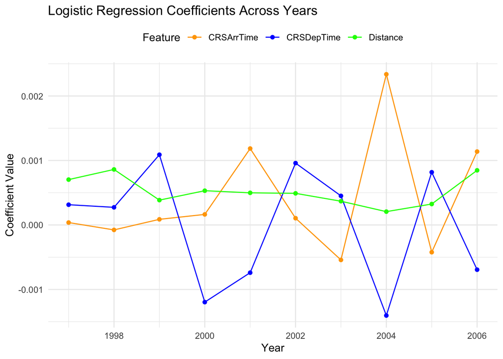

```r
ggplot(coefficients_long, aes(x = Year, y = Coefficient, color = Feature)) +
  geom_line() +
  geom_point() +
  labs(title = "Logistic Regression Coefficients Across Years",
       x = "Year",
       y = "Coefficient Value") +
  scale_color_manual(values = c( "CRSDepTime" = "blue",
                                "CRSArrTime" = "orange",
                                "Distance" = "green")) +
  theme_minimal() +
  theme(legend.position = "top")
```

### Disconnect from connection

```r
dbDisconnect(conn)
```